# Chapter 2 — Practice Challenge Solutions

←Back to the bookChapter 2 · Take the quiz & aim for 100%

Chapter 2 · Solutions

Practice Challenges, Worked Answers ✅

Full solutions to the five "Statistics, Data Science & AI" challenges, at least one in each field, all beginner level. Try them yourself first, then compare.

Statistics, Data Science and AI: A Visual Handbook · John Fisher · 2026

## ⚙️ Setup

Same clean style as the chapter notebook.

```python
import numpy as np
import pandas as pd
import matplotlib.pyplot as plt

NAVY="#0a1230"; INK="#1a2138"; INK_SOFT="#4a5578"
CYAN="#0891b2"; PURPLE="#7c3aed"; AMBER="#d97706"; GREEN="#059669"; PINK="#db2777"; BLUE="#2563eb"
GRID="#e6e9f2"
plt.rcParams.update({
    "figure.facecolor":"white","axes.facecolor":"white","figure.dpi":110,"font.size":11,
    "axes.edgecolor":GRID,"axes.linewidth":1.2,"axes.grid":True,"grid.color":GRID,"axes.axisbelow":True,
    "axes.spines.top":False,"axes.spines.right":False,
    "axes.titlesize":14,"axes.titleweight":"bold","axes.titlecolor":INK,
    "axes.labelcolor":INK_SOFT,"xtick.color":INK_SOFT,"ytick.color":INK_SOFT,"legend.frameon":False,
})
print("✅ Ready.")
```

```
✅ Ready.
```

CHALLENGE 1 · STATISTICS

Summarize the week

Daily steps for a week: `[5000, 7000, 8000, 6000, 10000, 9000, 7000]`. Find the mean and the range.

```python
steps = pd.Series([5000, 7000, 8000, 6000, 10000, 9000, 7000])
mean_steps = steps.mean()
range_steps = steps.max() - steps.min()
print(f"Mean  : {mean_steps:.0f} steps/day")
print(f"Range : {range_steps} steps  (max {steps.max()} - min {steps.min()})")
```

```
Mean  : 7429 steps/day
Range : 5000 steps  (max 10000 - min 5000)
```

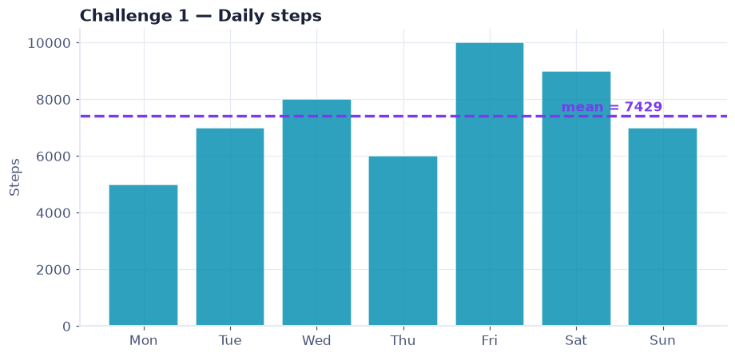

```python
fig, ax = plt.subplots(figsize=(8.5,4.2))
dlabels = ["Mon","Tue","Wed","Thu","Fri","Sat","Sun"]
ax.bar(dlabels, steps, color=CYAN, alpha=0.85, edgecolor="white")
ax.axhline(mean_steps, color=PURPLE, ls="--", lw=2.2)
ax.text(6, mean_steps+150, f"mean = {mean_steps:.0f}", color=PURPLE, fontweight="bold", ha="right")
ax.set_title("Challenge 1 — Daily steps", loc="left")
ax.set_ylabel("Steps")
plt.tight_layout(); plt.show()
```

**Answer:** Mean ≈ **7,429 steps/day**, Range = **5,000 steps** (10,000 − 5,000). This is *descriptive* statistics, summarizing the data we have.

CHALLENGE 2 · STATISTICS

Explain or predict?

Label each question as **EXPLAIN** (statistics) or **PREDICT** (machine learning).

```python
qs = [
  ("Is there a relationship between hours slept and test scores?", "EXPLAIN (statistics)"),
  ("Will this specific customer cancel their subscription next month?", "PREDICT (machine learning)"),
  ("What was our average daily revenue last quarter?", "EXPLAIN / describe (statistics)"),
]
for q, a in qs:
    print(f"• {q}\n    -> {a}\n")
```

```
• Is there a relationship between hours slept and test scores?
    -> EXPLAIN (statistics)

• Will this specific customer cancel their subscription next month?
    -> PREDICT (machine learning)

• What was our average daily revenue last quarter?
    -> EXPLAIN / describe (statistics)
```

**Answer:** Questions about *relationships* or *summaries* of existing data are **explanation/description (statistics)**. Questions about *what will happen for a new case* are **prediction (machine learning)**.

CHALLENGE 3 · DATA SCIENCE

Clean, then summarize

Survey ages: `[22, 25, None, 30, 28]` (one value is missing). (a) What cleaning step is needed? (b) Find the mean of the known ages.

```python
ages = pd.Series([22, 25, None, 30, 28])
print("Raw ages:", list(ages))
print("Missing values:", int(ages.isna().sum()))

# (a) Cleaning step: handle the missing value.
# (b) Mean of the KNOWN ages (pandas .mean() skips missing automatically):
print(f"Mean of known ages: {ages.mean():.1f}")

# A common cleaning choice: fill the gap with that mean
filled = ages.fillna(round(ages.mean(), 1))
print("After filling the gap:", list(filled))
```

```
Raw ages: [22.0, 25.0, nan, 30.0, 28.0]
Missing values: 1
Mean of known ages: 26.2
After filling the gap: [22.0, 25.0, 26.2, 30.0, 28.0]
```

**Answer:** (a) The data must be **cleaned**, handle the missing value (drop it or fill it, e.g. with the mean). (b) Mean of the four known ages = **26.25**. Cleaning *before* analysis is a core data-science habit.

CHALLENGE 4 · MACHINE LEARNING

Features vs label

A model predicts a house's **price** from its **size**, **bedrooms**, and **age**. Which columns are the features (inputs) and which is the label (target)?

```python
houses = pd.DataFrame({
    "size_sqft":  [900, 1200, 1500, 2000],
    "bedrooms":   [2, 3, 3, 4],
    "age_years":  [30, 12, 8, 2],
    "price_k":    [180, 250, 310, 420],   # <- this is what we want to predict
})

label   = "price_k"
features = [c for c in houses.columns if c != label]
print("FEATURES (inputs the model learns from):", features)
print("LABEL    (the target we predict)       :", label)
houses
```

```
FEATURES (inputs the model learns from): ['size_sqft', 'bedrooms', 'age_years']
LABEL    (the target we predict)       : price_k
```

|  | size_sqft | bedrooms | age_years | price_k |
| --- | --- | --- | --- | --- |
| 0 | 900 | 2 | 30 | 180 |
| 1 | 1200 | 3 | 12 | 250 |
| 2 | 1500 | 3 | 8 | 310 |
| 3 | 2000 | 4 | 2 | 420 |

**Answer:** **Features** = `size_sqft`, `bedrooms`, `age_years` (the inputs). **Label** = `price_k` (the thing we predict). Every supervised-ML problem is "features → label."

CHALLENGE 5 · ALL THREE TOGETHER

Who does what?

A streaming service. Match each task to **Statistics**, **Machine Learning**, or **Data Science**.

```python
tasks = {
  "Report the average watch time per user this month": "STATISTICS (summarize data)",
  "Predict which show a user will watch next":          "MACHINE LEARNING (predict)",
  "Build the full recommendation product end-to-end":   "DATA SCIENCE (the whole pipeline)",
}
for task, field in tasks.items():
    print(f"• {task}\n    -> {field}\n")
```

```
• Report the average watch time per user this month
    -> STATISTICS (summarize data)

• Predict which show a user will watch next
    -> MACHINE LEARNING (predict)

• Build the full recommendation product end-to-end
    -> DATA SCIENCE (the whole pipeline)
```

**Answer:** summarizing existing numbers = **Statistics**; predicting a new outcome = **Machine Learning**; combining data, stats, ML, code and domain knowledge into a working product = **Data Science**. They complement each other, statistics is the foundation, ML adds prediction, data science delivers the whole solution.

🎉 Nicely done!

You summarized data (statistics), told explanation from prediction, cleaned a dataset (data science), spotted features vs label (machine learning), and matched real tasks to all three fields. That's the big picture of how they fit together.

Statistics, Data Science and AI: A Visual Handbook · © 2026 John Fisher

←Back to the bookChapter 2 · Take the quiz & aim for 100%